# Lab-04-McCullers

Caitlyn McCullers

4/12/2022

```r
import::here("S_TYPE",
             "panel.cor",
             "panel.smooth",
             "jplot",
             "d",
             "df",
             "cbsa_stats_df",
             .from = here::here("labs/wk04/lab_04_source.R"),
             .character_only = TRUE)
```

## Part 1, Data

```r
import::here("clean_d",
             "tidy_up_data",
             "build_year",
             "RELEVANT_FILES",
             "obtain_crosswalk",
             "create_final_metadata_file",
             # notice the use of here::here() that points to the .R file
             # where all these R objects are created
             .from = here::here("labs/wk03/utilities.R"),
             .character_only = TRUE)
```

```r
d1 <- readRDS( here::here( "data/rodeo/LTDB-2000.rds" ) )
d2 <- readRDS( here::here( "data/rodeo/LTDB-2010.rds" ) )
md <- readRDS( here::here( "data/rodeo/LTDB-META-DATA.rds" ) )
```

```r
d1 <- select( d1, - year )
d2 <- select( d2, - year )

d <- merge( d1, d2, by="tractid" )
d <- merge( d, md, by="tractid" )
```

#### Filter to just urban tracts

```r
table( d$urban )
```

```
##
## rural urban
## 12971 59722
```

```r
d <- filter( d, urban == "urban" )
```

```r
# find variables that are in both files
compare_dfs <- function( df1, df2 )
{
  # use regular expressions to remove numeric suffixes
  var.names.1 <- names( df1 )
  var.names.1 <- gsub( "[.][xy]$", "", var.names.1 )
  var.names.1 <- gsub( "[0-9]{2}$", "", var.names.1 )

  var.names.2 <- names( df2 )
  var.names.2 <- gsub( "[.][xy]$", "", var.names.2 )
  var.names.2 <- gsub( "[0-9]{2}$", "", var.names.2 )

  shared <- intersect( var.names.1, var.names.2 ) %>% sort()
  print( "SHARED VARIABLES:")
  print( shared )

  not.shared <- c( setdiff( var.names.1, var.names.2 ),
                   setdiff( var.names.2, var.names.1 ) ) %>% sort()

  print( "NOT SHARED:" )
  print( not.shared )

  d.vars1 <- data.frame( type="shared", variables=shared, stringsAsFactors=F )
  d.vars2 <- data.frame( type="not shared", variables=not.shared, stringsAsFactors=F )
  dd <- rbind( d.vars1, d.vars2 )

  return( dd )
}

vars <- compare_dfs( df1=d1, df2=d2 )
```

```
## [1] "SHARED VARIABLES:"
##   [1] "a15asn"  "a15blk"  "a15hsp"  "a15ntv"  "a15wht"  "a18und"  "a60asn"
##   [8] "a60blk"  "a60hsp"  "a60ntv"  "a60up"   "a60wht"  "a75up"   "ag15up"
##  [15] "ag18cv"  "ag25up"  "ag5up"   "ageasn"  "ageblk"  "agehsp"  "agentv"
##  [22] "agewht"  "asian"   "china"   "clf"     "col"     "cuban"   "dapov"
##  [29] "dbpov"   "dflabf"  "dfmpov"  "dhpov"   "dmulti"  "dnapov"  "dpov"
##  [36] "dwpov"   "empclf"  "family"  "fb"      "fhh"     "filip"   "flabf"
##  [43] "geanc"   "gefb"    "h10yrs"  "h30old"  "haw"     "hh"      "hha"
##  [50] "hhb"     "hhh"     "hhw"     "hinc"    "hinca"   "hincb"   "hinch"
##  [57] "hincw"   "hisp"    "hs"      "hu"      "incpc"   "india"   "iranc"
##  [64] "irfb"    "itanc"   "itfb"    "japan"   "korea"   "lep"     "manuf"
##  [71] "mar"     "mex"     "mhmval"  "mrent"   "multi"   "n10imm"  "n65pov"
##  [78] "napov"   "nat"     "nbpov"   "nfmpov"  "nhblk"   "nhpov"   "nhwht"
##  [85] "nnapov"  "npov"    "ntv"     "nwpov"   "ohu"     "olang"   "own"
##  [92] "pop"     "pr"      "prof"    "rent"    "ruanc"   "rufb"    "scanc"
##  [99] "scfb"    "semp"    "tractid" "unemp"   "vac"     "vet"     "viet"
## [106] "wds"
## [1] "NOT SHARED:"
##  [1] "a65asn"  "a65blk"  "a65hsp"  "a65ntv"  "a65wht"  "cni16u"  "dis"
##  [8] "hu00sp"  "ohu00sp" "p10imm"  "p10yrs"  "p15asn"  "p15blk"  "p15hsp"
## [15] "p15ntv"  "p15wht"  "p18und"  "p30old"  "p60up"   "p65asn"  "p65blk"
## [22] "p65hsp"  "p65ntv"  "p65pov"  "p65wht"  "p75up"   "papov"   "pasian"
## [29] "pbpov"   "pchina"  "pcol"    "pcuban"  "pfb"     "pfhh"    "pfilip"
## [36] "pflabf"  "pfmpov"  "pgeanc"  "pgefb"   "phaw"    "phisp"   "phpov"
## [43] "phs"     "pindia"  "piranc"  "pirfb"   "pitanc"  "pitfb"   "pjapan"
## [50] "pkorea"  "plep"    "pmanuf"  "pmar"    "pmex"    "pmulti"  "pnapov"
## [57] "pnat"    "pnhblk"  "pnhwht"  "pntv"    "polang"  "pown"    "ppov"
## [64] "ppr"     "pprof"   "pruanc"  "prufb"   "pscanc"  "pscfb"   "psemp"
## [71] "punemp"  "pvac"    "pvet"    "pviet"   "pwds"    "pwpov"
```

```r
d.full <- d
```

#### 2000-2010 variables

```r
d <- d.full

d <- select( d, tractid, mhmval00, mhmval12, hinc00,
             hu00, own00, rent00,
             empclf00, clf00, unemp00, prof00,
             dpov00, npov00,
             ag25up00, hs00, col00,
             pop00.x, nhwht00, nhblk00, hisp00, asian00,
             cbsa, cbsaname )
d <-
  d %>%
  mutate( p.white = 100 * nhwht00 / pop00.x,
          p.black = 100 * nhblk00 / pop00.x,
          p.hisp = 100 * hisp00 / pop00.x,
          p.asian = 100 * asian00 / pop00.x,
          p.hs = 100 * (hs00+col00) / ag25up00,
          p.col = 100 * col00 / ag25up00,
          p.prof = 100 * prof00 / empclf00,
          p.unemp = 100 * unemp00 / clf00,
          pov.rate = 100 * npov00 / dpov00 )
```

```r
# adjust 2000 home values for inflation
mhv.00 <- d$mhmval00 * 1.28855
mhv.10 <- d$mhmval12

mhv.change <- mhv.10 - mhv.00

df <- data.frame( MedianHomeValue2000=mhv.00,
                  MedianHomeValue2010=mhv.10,
                  Change.00.to.10=mhv.change )

stargazer( df,
           type=S_TYPE,
           digits=0,
           summary.stat = c("min", "p25","median","mean","p75","max") )
```

| Statistic | Min | Pctl(25) | Median | Mean | Pctl(75) | Max |
| --- | --- | --- | --- | --- | --- | --- |
| MedianHomeValue2000 | 0 | 105,146 | 154,497 | 186,502 | 224,071 | 1,288,551 |
| MedianHomeValue2010 | 9,999 | 123,200 | 193,200 | 246,570 | 312,000 | 1,000,001 |
| Change.00.to.10 | -1,228,651 | 7,187 | 36,268 | 60,047 | 94,881 | 1,000,001 |

#### Change in MHV 2000-2010

```r
#filter out properties valued under $10,000 in 2000

mhv.00[ mhv.00 < 10000 ] <- NA
pct.change <- mhv.change / mhv.00
summary( pct.change )
```

```
##     Min.  1st Qu.   Median     Mean  3rd Qu.     Max.     NA's
## -0.96891  0.05918  0.25402  0.33167  0.49556 60.59261      220
```

#### Group growth rates by metro area

```r
d$mhv.change <- mhv.change
d$pct.change <- pct.change
d$mhv.10 <- mhv.10
d$mhv.00 <- mhv.00
```

#### Select gentrification variables

```r
d.full$mhv.00 <- mhv.00
d.full$mhv.10 <- mhv.10
d.full$mhv.change <- mhv.change
d.full$pct.change <- pct.change
```

```r
d3 <- select( d.full,

             tractid, cbsa, cbsaname,            # ids / units of analysis

             mhv.00, mhv.10, mhv.change, pct.change,    # home value

             hinc00, hu00, own00, rent00,        # ses
             hinc12, hu10, own10, rent10,

             empclf00, clf00, unemp00, prof00,   # employment
             empclf12, clf12, unemp12, prof12,

             dpov00, npov00,                     # poverty
             dpov12, npov12,

             ag25up00, hs00, col00,              # education
             ag25up12, hs12, col12,

             pop00.x, nhwht00, nhblk00, hisp00, asian00,   # race
             pop10, nhwht10, nhblk10, hisp10, asian10

          ) # end select

d3 <-
  d3 %>%
  mutate(
          # 2000 variables
          p.white.00 = 100 * nhwht00 / pop00.x,
          p.black.00 = 100 * nhblk00 / pop00.x,
          p.hisp.00 = 100 * hisp00 / pop00.x,
          p.asian.00 = 100 * asian00 / pop00.x,
          p.hs.edu.00 = 100 * (hs00+col00) / ag25up00,
          p.col.edu.00 = 100 * col00 / ag25up00,
          p.prof.00 = 100 * prof00 / empclf00,
          p.unemp.00 = 100 * unemp00 / clf00,
          pov.rate.00 = 100 * npov00 / dpov00,

          # 2010 variables
          p.white.10 = 100 * nhwht10 / pop10,
          p.black.10 = 100 * nhblk10 / pop10,
          p.hisp.10 = 100 * hisp10 / pop10,
          p.asian.10 = 100 * asian10 / pop10,
          p.hs.edu.10 = 100 * (hs12+col12) / ag25up12,
          p.col.edu.10 = 100 * col12 / ag25up12,
          p.prof.10 = 100 * prof12 / empclf12,
          p.unemp.10 = 100 * unemp12 / clf12,
          pov.rate.10 = 100 * npov12 / dpov12 )
```

```r
d3 <-
  d3 %>%
  group_by( cbsaname ) %>%
  mutate( metro.mhv.pct.00 = ntile( mhv.00, 100 ),
          metro.mhv.pct.10 = ntile( mhv.10, 100 ),
          metro.median.pay.00 = median( hinc00, na.rm=T ),
          metro.median.pay.10 = median( hinc12, na.rm=T ),
          metro.race.rank.00 = ntile( (100-p.white.00), 100 ) ) %>%
  ungroup() %>%
  mutate( metro.mhv.pct.change = metro.mhv.pct.10 - metro.mhv.pct.00,
          pay.change = metro.median.pay.10 - metro.median.pay.00,
          race.change = p.white.10 - p.white.00,
          mhv.change = mhv.10 - mhv.00 )
```

#### Descriptive statistics of change variables

```r
d3 <-
  d3 %>%
  select( c( "tractid", "cbsa", "cbsaname",
             "mhv.00", "mhv.10", "mhv.change","pct.change",
          "p.white.00", "p.black.00", "p.hisp.00", "p.asian.00",
          "p.hs.edu.00", "p.col.edu.00", "p.prof.00",  "p.unemp.00",
          "pov.rate.00", "p.white.10", "p.black.10", "p.hisp.10",
          "p.asian.10", "p.hs.edu.10", "p.col.edu.10", "p.prof.10",
          "p.unemp.10", "pov.rate.10", "metro.mhv.pct.00",
          "metro.mhv.pct.10", "metro.median.pay.00", "metro.median.pay.10",
          "metro.mhv.pct.change", "pay.change", "race.change",
          "metro.race.rank.00") )

d3 <- data.frame(d3)
stargazer( d3,
           type=S_TYPE,
           digits=0,
           summary.stat = c("min", "p25","median","mean","p75","max") )
```

| Statistic | Min | Pctl(25) | Median | Mean | Pctl(75) | Max |
| --- | --- | --- | --- | --- | --- | --- |
| mhv.00 | 11,167 | 105,661 | 154,903 | 187,129 | 224,337 | 1,288,551 |
| mhv.10 | 9,999 | 123,200 | 193,200 | 246,570 | 312,000 | 1,000,001 |
| mhv.change | -1,228,651 | 7,101 | 35,981 | 59,372 | 94,140 | 983,765 |
| pct.change | -1 | 0 | 0 | 0 | 0 | 61 |
| p.white.00 | 0 | 47 | 78 | 67 | 91 | 100 |
| p.black.00 | 0 | 1 | 4 | 14 | 14 | 100 |
| p.hisp.00 | 0 | 2 | 4 | 13 | 15 | 100 |
| p.asian.00 | 0 | 1 | 2 | 5 | 5 | 95 |
| p.hs.edu.00 | 0 | 67 | 72 | 72 | 77 | 100 |
| p.col.edu.00 | 0 | 12 | 21 | 26 | 36 | 100 |
| p.prof.00 | 0 | 23 | 31 | 34 | 43 | 100 |
| p.unemp.00 | 0 | 3 | 5 | 6 | 8 | 100 |
| pov.rate.00 | 0 | 4 | 9 | 12 | 17 | 100 |
| p.white.10 | 0 | 37 | 70 | 60 | 87 | 100 |
| p.black.10 | 0 | 2 | 5 | 15 | 17 | 100 |
| p.hisp.10 | 0 | 3 | 7 | 17 | 21 | 100 |
| p.asian.10 | 0 | 1 | 3 | 6 | 6 | 96 |
| p.hs.edu.10 | 0 | 66 | 71 | 71 | 77 | 100 |
| p.col.edu.10 | 0 | 15 | 25 | 30 | 41 | 100 |
| p.prof.10 | 0 | 24 | 34 | 35 | 46 | 100 |
| p.unemp.10 | 0 | 6 | 9 | 10 | 13 | 100 |
| pov.rate.10 | 0 | 6 | 12 | 16 | 22 | 100 |
| metro.mhv.pct.00 | 1 | 20 | 41 | 45 | 68 | 100 |
| metro.mhv.pct.10 | 1 | 20 | 41 | 45 | 68 | 100 |
| metro.median.pay.00 | 23,012 | 39,457 | 43,139 | 45,054 | 49,522 | 73,701 |
| metro.median.pay.10 | 30,337 | 47,736 | 54,728 | 55,905 | 60,119 | 96,033 |
| metro.mhv.pct.change | -99 | -6 | -1 | 0 | 4 | 99 |
| pay.change | -3,207 | 7,495 | 9,764 | 10,851 | 13,809 | 27,310 |
| race.change | -100 | -10 | -5 | -6 | -1 | 90 |
| metro.race.rank.00 | 1 | 20 | 41 | 45 | 68 | 100 |

#### Remove tracts where properties were worth less than $10,000 in 2000

```r
mhv.00[ mhv.00 < 10000 ] <- NA
pct.change <- 100 * ( mhv.change / mhv.00 )
summary( pct.change )
```

```
##     Min.  1st Qu.   Median     Mean  3rd Qu.     Max.     NA's
##  -96.891    5.918   25.402   33.167   49.556 6059.261      220
```

#### Remove tracts with growth above 200%

```r
pct.change[ pct.change > 200 ] <- NA
```

## Part 2, Predict MHV Change

## Select at least three census variables that you feel will be good predictors of change in MHV between 2000 and 2010.

- Percent white residents in 2000 (p.white.00)
- Percent with 4-year college education or more (p.col.edu.00)
- Poverty rate in 2000 (pov.rate.00)

#### Check for variable skew

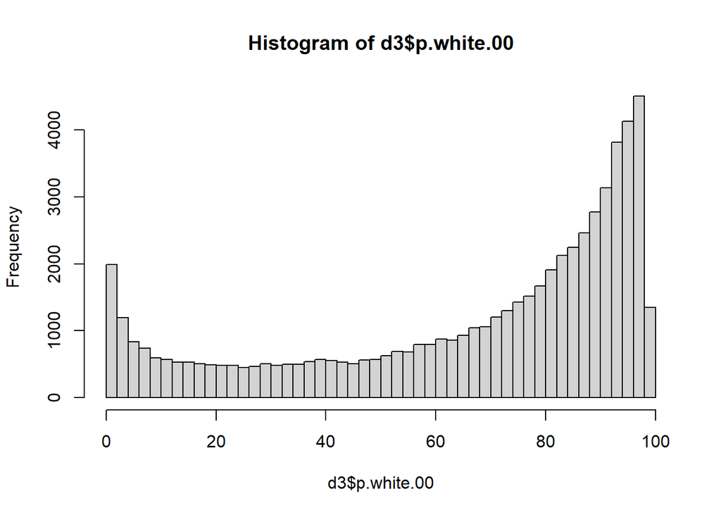

```r
hist( d3$p.white.00, breaks = 50 )
```

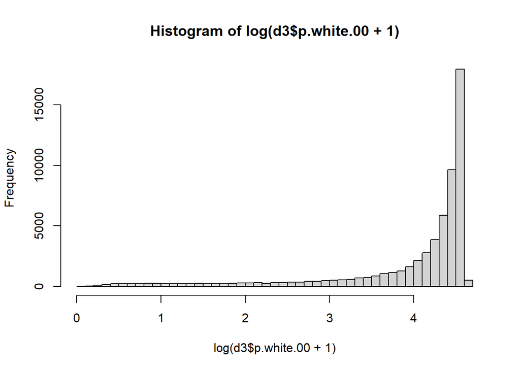

```r
hist( log( d3$p.white.00 + 1), breaks = 50 )
```

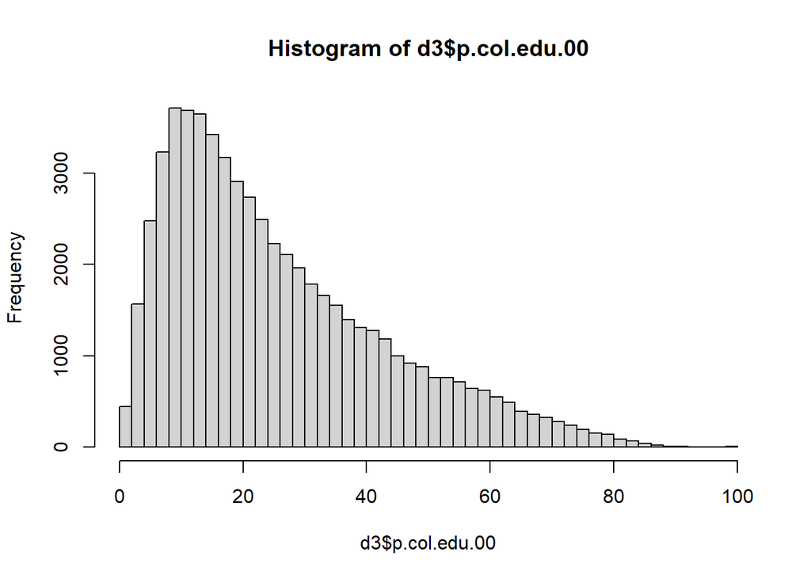

```r
hist( d3$p.col.edu.00, breaks = 50 )
```

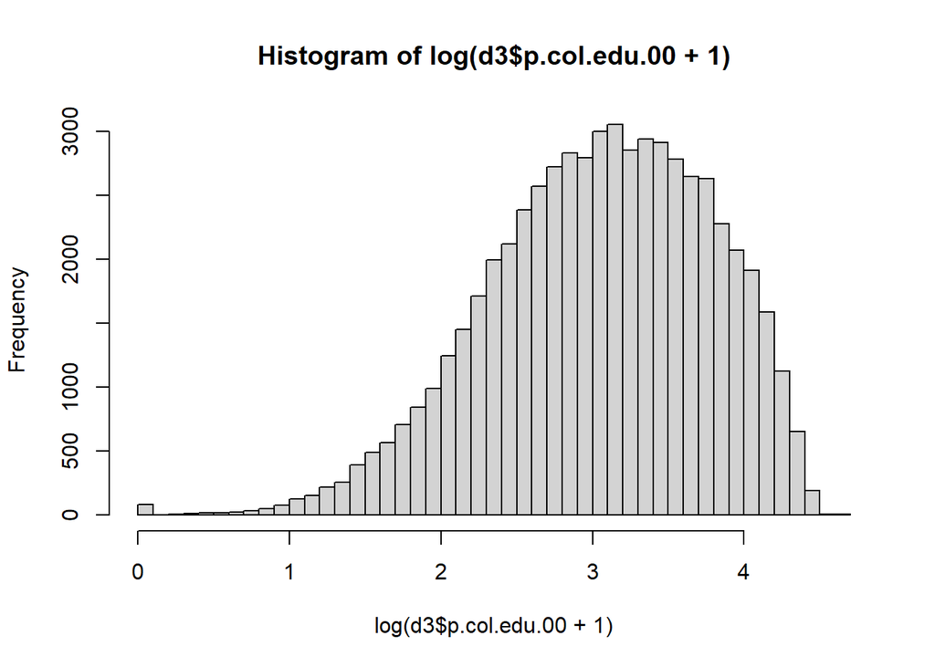

```r
hist( log( d3$p.col.edu.00 + 1 ), breaks = 50 )
```

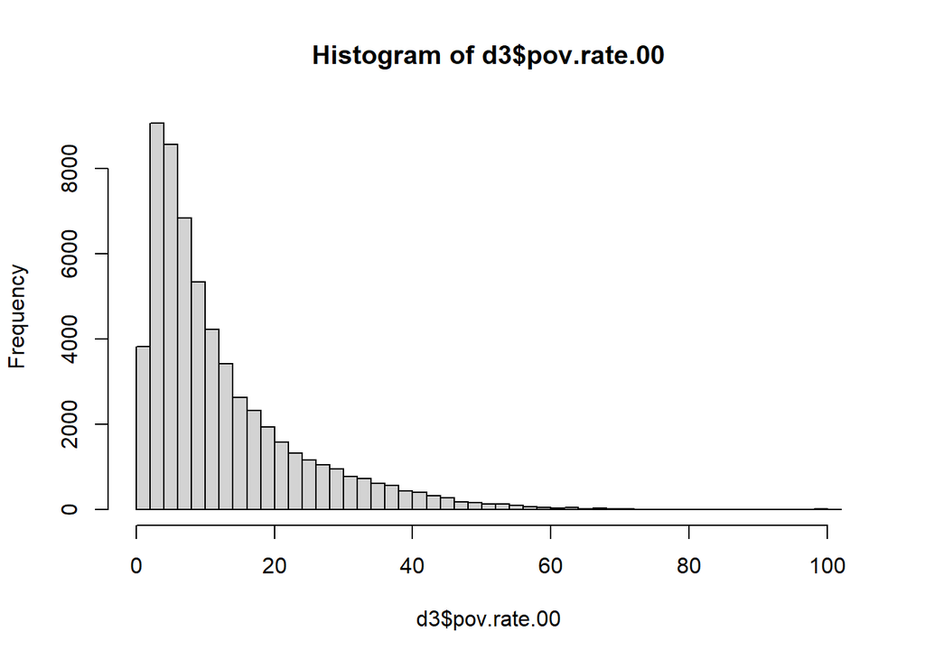

```r
hist( d3$pov.rate.00, breaks = 50 )
```

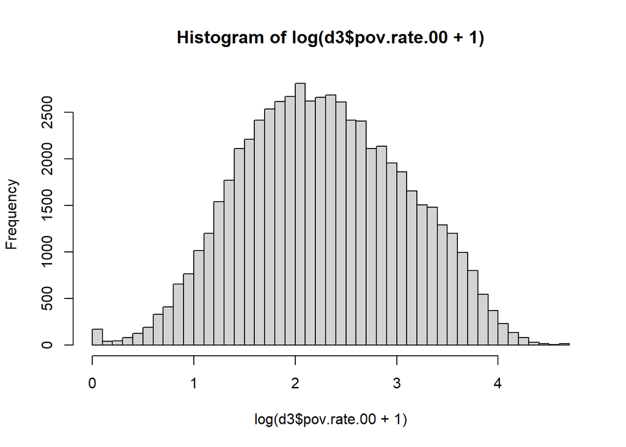

```r
hist( log( d3$pov.rate.00 + 1 ), breaks = 50 )
```

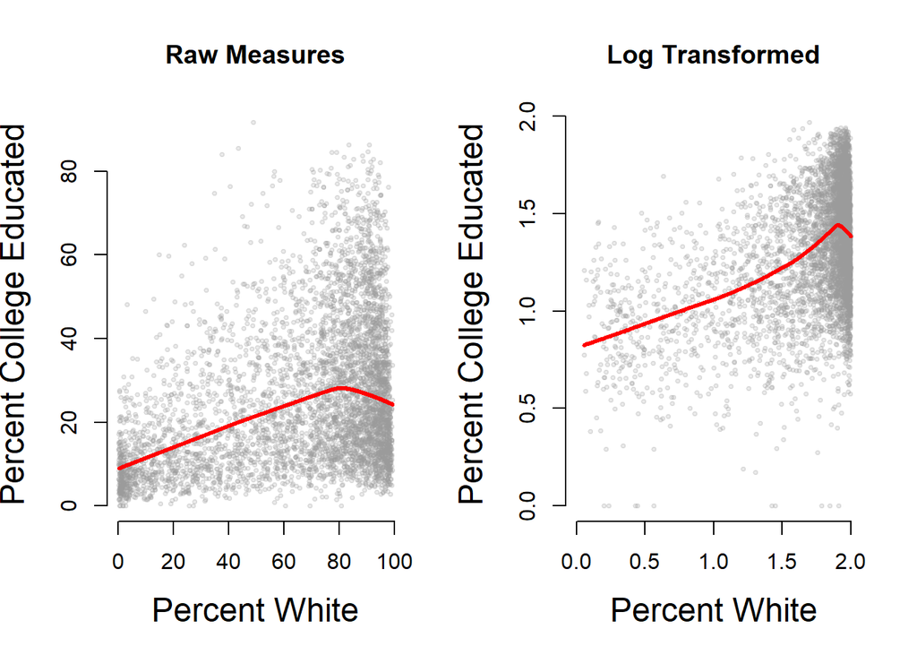

```r
log.p.white.00 <- log10( d3$p.white.00 + 1 )
log.p.col.edu.00 <- log10( d3$p.col.edu.00 + 1 )

par( mfrow=c( 1, 2 ))

these <- sample( 1:length( log.p.white.00), 5000 )

jplot( d3$p.white.00[these], d3$p.col.edu.00[these],
       lab1 = "Percent White", lab2 = "Percent College Educated",
       main = "Raw Measures" )

jplot( log.p.white.00[these], log.p.col.edu.00[these],
       lab1 = "Percent White", lab2 = "Percent College Educated",
       main = "Log Transformed" )
```

```r
cor( d3$p.white.00, d3$p.col.edu.00, use = "pairwise.complete" )
```

```
## [1] 0.3679272
```

```r
cor( log.p.white.00, log.p.col.edu.00, use = "pairwise.complete" )
```

```
## [1] 0.4739508
```

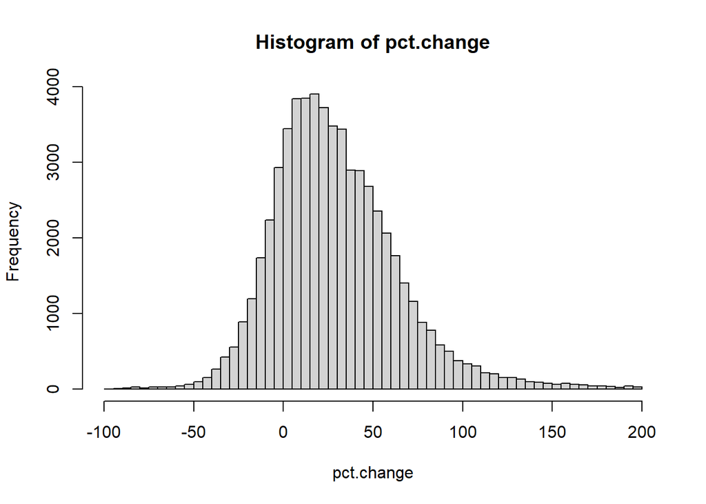

```r
hist( pct.change, breaks = 50 )
```

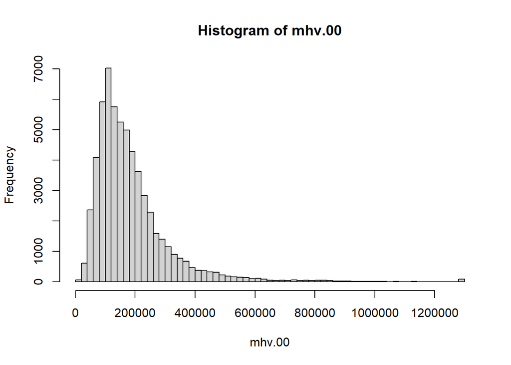

```r
hist( mhv.00, breaks = 50 )
```

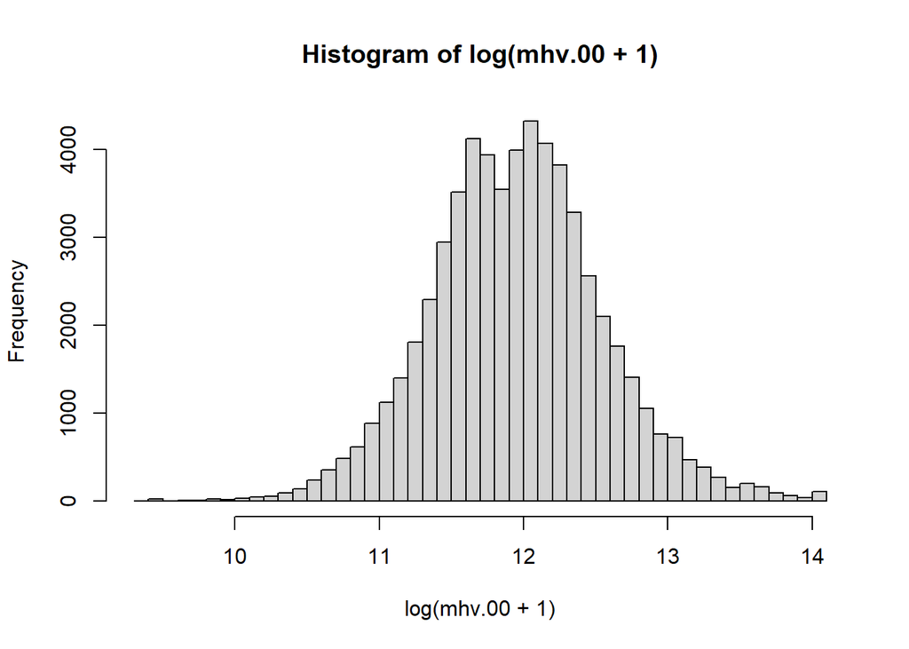

```r
hist( log( mhv.00 + 1 ), breaks = 50 )
```

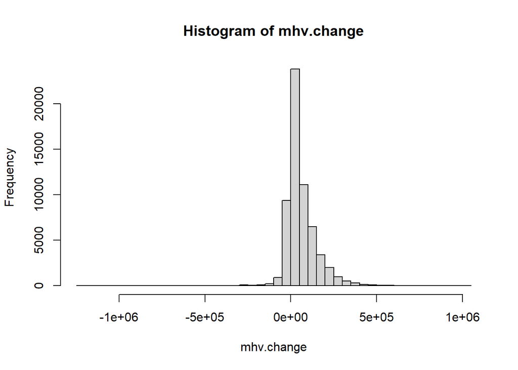

```r
hist( mhv.change, breaks = 50 )
```

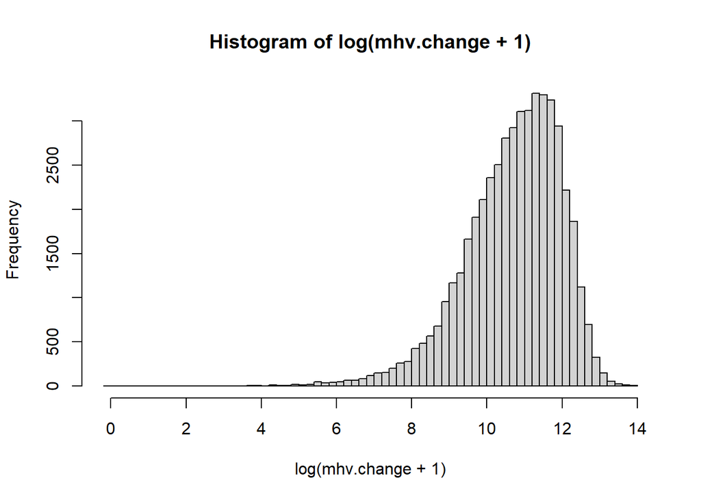

```r
hist( log( mhv.change + 1 ), breaks = 50 )
```

#### Check for multicollinearity

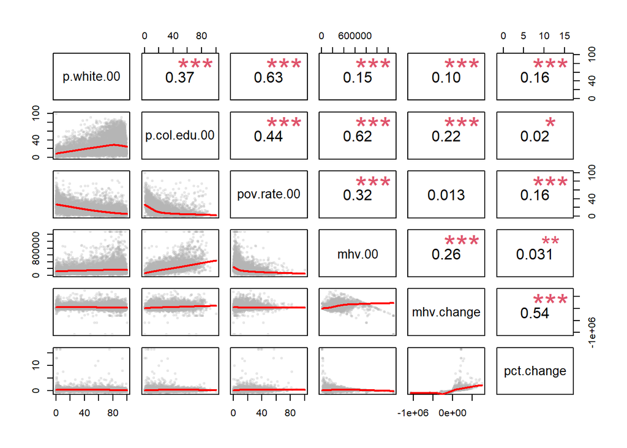

```r
# Correlations of raw scores

d4 <- select( d3, p.white.00, p.col.edu.00, pov.rate.00, mhv.00, mhv.change, pct.change )

set.seed( 1234 )
d4 <- sample_n( d4, 10000 ) %>% na.omit()

pairs( d4, upper.panel=panel.cor, lower.panel=panel.smooth )
```

```r
# Correlations of logged scores

set.seed( 1234 )

d4 <- select( d3, p.white.00, p.col.edu.00, pov.rate.00, mhv.change )

d4$p.white.00 <- log10( d4$p.white.00 + 1 )
d4$p.col.edu.00 <- log10( d4$p.col.edu.00 + 1 )
d4$pov.rate.00 <- log10( d4$pov.rate.00 + 1 )
d4$mhv.change <- log10( d4$mhv.change + 1 )
```

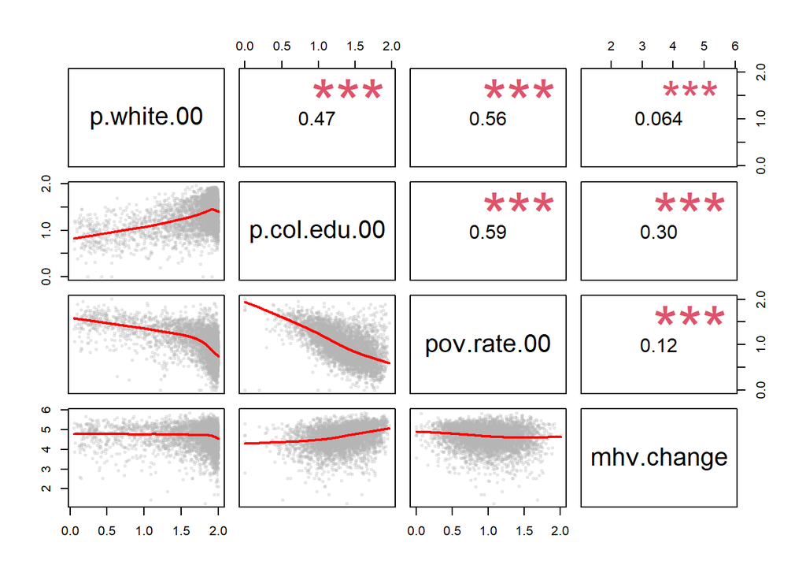

```r
d5 <- sample_n( d4, 5000 ) %>% na.omit()

pairs( d5, upper.panel = panel.cor, lower.panel = panel.smooth )
```

#### Regression models with metro-area fixed effects

```r
d.reg <- d

d.reg$mhv.change[ d.reg$mhv.change > 200 ] <- NA
d.reg$p.white <- log10( d.reg$p.white + 1 )
d.reg$p.col <- log10( d.reg$p.col + 1 )
d.reg$pov.rate <- log10( d.reg$pov.rate + 1 )

# average growth in median home value for the city
d.reg <-
  d.reg %>%
  group_by( cbsaname ) %>%
  mutate( metro.mhv.growth = 100 * median( mhv.change, na.rm=T ) ) %>%
  ungroup()
```

#### Each variable alone (with metro-area fixed effects)

```r
m1 <- lm( mhv.change ~ p.white + cbsa, data = d.reg )
m2 <- lm( mhv.change ~ p.col + cbsa, data = d.reg )
m3 <- lm( mhv.change ~ pov.rate + cbsa, data = d.reg )

stargazer( m1, m2, m3,
           type = S_TYPE, digits = 2,
           omit.stat = c( "rsq", "f" ),
           omit = "cbsa" )
```

|  | *Dependent variable:* |  |  |
| --- | --- | --- | --- |
|  | mhv.change |  |  |
|  | (1) | (2) | (3) |
| p.white | -13,270.40*** |  |  |
|  | (1,450.83) |  |  |
| p.col |  | -31,877.37*** |  |
|  |  | (1,737.58) |  |
| pov.rate |  |  | 11,222.75*** |
|  |  |  | (1,584.45) |
| Constant | 20,117.36 | 31,473.69 | -18,495.54 |
|  | (21,920.64) | (21,589.58) | (21,880.36) |
| Observations | 10,832 | 10,831 | 10,831 |
| Adjusted R<sup>2</sup> | 0.30 | 0.31 | 0.29 |
| Residual Std. Error | 53,289.41 (df = 10499) | 52,665.34 (df = 10498) | 53,375.52 (df = 10498) |
| *Note:* | p<0.1; p<0.05; p<0.01 |  |  |

#### Regression with multiple variables

```r
m1 <- lm( mhv.change ~ p.white + p.col + cbsa, data=d.reg )
m2 <- lm( mhv.change ~ p.white + pov.rate + cbsa, data = d.reg)
m3 <- lm( mhv.change ~ pov.rate + p.col + cbsa, data = d.reg )
m4 <- lm( mhv.change ~ p.white + p.col + pov.rate + cbsa, data=d.reg)

stargazer( m1, m2, m3, m4,
           type= S_TYPE, digits=2,
           omit.stat = c("rsq","f"),
           omit="cbsa" )
```

|  | *Dependent variable:* |  |  |  |
| --- | --- | --- | --- | --- |
|  | mhv.change |  |  |  |
|  | (1) | (2) | (3) | (4) |
| p.white | -1,552.84 | -11,038.40*** |  | -6,298.63*** |
|  | (1,614.00) | (1,781.71) |  | (1,780.07) |
| p.col | -31,014.36*** |  | -39,030.21*** | -37,789.12*** |
|  | (1,955.46) |  | (2,204.58) | (2,231.11) |
| pov.rate |  | 4,239.12** | -10,435.06*** | -13,731.31*** |
|  |  | (1,942.22) | (1,983.54) | (2,190.42) |
| Constant | 33,376.92 | 10,682.33 | 52,586.10** | 66,975.02*** |
|  | (21,680.09) | (22,343.50) | (21,932.48) | (22,294.45) |
| Observations | 10,831 | 10,831 | 10,831 | 10,831 |
| Adjusted R<sup>2</sup> | 0.31 | 0.30 | 0.31 | 0.31 |
| Residual Std. Error | 52,665.53 (df = 10497) | 53,280.74 (df = 10497) | 52,598.55 (df = 10497) | 52,569.71 (df = 10496) |
| *Note:* | p<0.1; p<0.05; p<0.01 |  |  |  |

## Part 3 Results

Model 4 with all three variables included produced an Adjusted R2 of 0.31, significant at the p<0.01 level. The direction for each of these coefficients was negative, thus a higher percentage of white residents, higher percentage with a college education, or higher poverty rate all indicate a decrease in median home values.

I expected to see these relationships for percent of white and college-educated residents, since tracts with these demographics may already be high-priced and not eligible for gentrification (and I also expect the converse, that areas with low white and college-educated populations may be ripe for gentrification). However, I am surprised to see that poverty rate is also a negative association. (Perhaps there is a multicollinearity issue with the other variables, especially college-education, since the direction of the association does not change until model 3.)